# STA 141 project

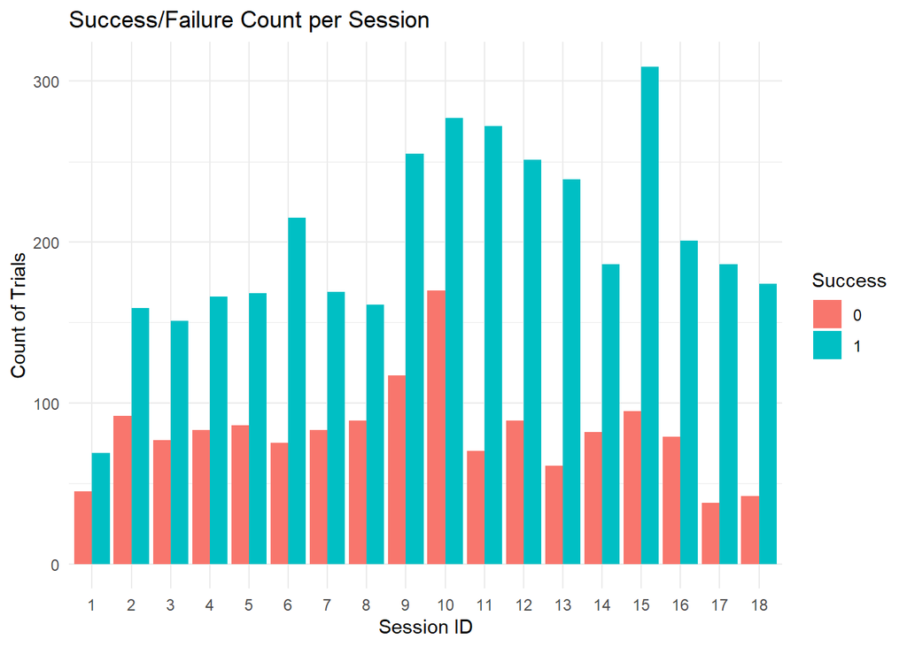

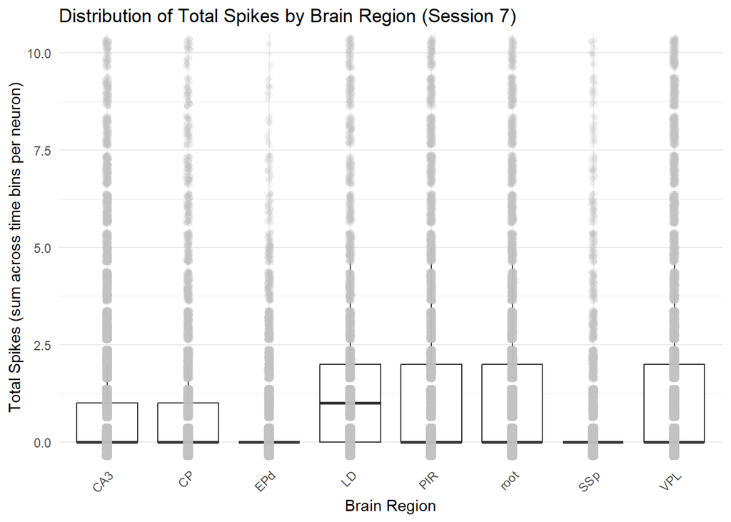

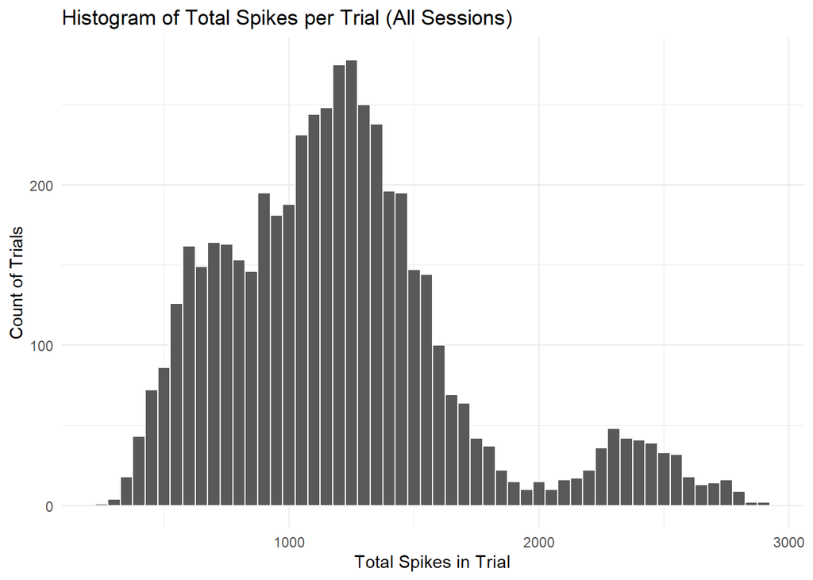

This histogram shows the distribution of total spike counts per trial across all sessions. The bulk of the data clusters around 800–1200 spikes, indicating that most trials fall within this moderate spike range. There is a noticeable right tail extending beyond 2000 spikes, representing trials with particularly high neural firing. This pattern suggests that while the majority of trials exhibit moderate overall activity, a subset experiences more intense neuronal responses. Differences in trial-level spikes may stem from variations in stimulus contrast, brain region involvement, or individual subject differences.

```
##
## === Performing PCA on time-bin features and plotting results ===
```

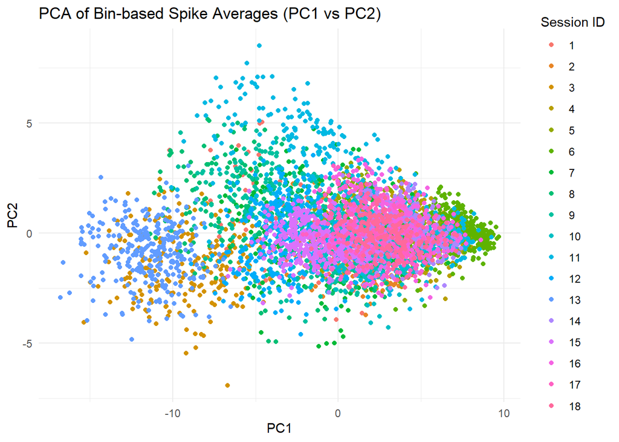

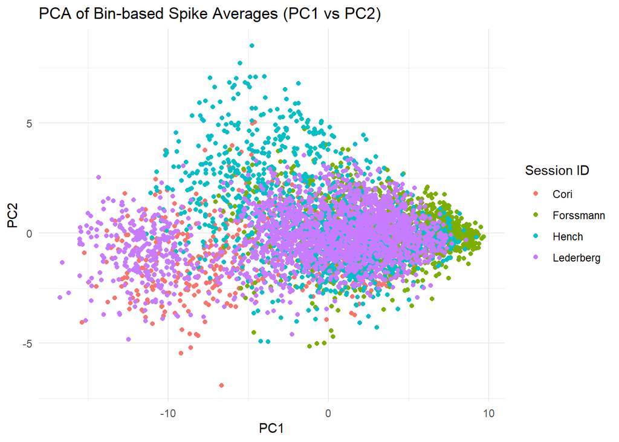

```
##
## Visualizations complete.
```

This plot displays the PCA scatter plot (PC1 vs. PC2) for time-bin-based average spike rates from four mice (Cori, Forssmann, Hench, Lederberg) Key findings: Most data points spread horizontally from negative to positive PC1 values, suggesting that PC1 is a dominant source of variation among trials. There is also noticeable spread along PC2, indicating secondary differences among trials in this second principal component

```
## Design matrix X built with dimensions: 5081 46
```

```
## Training set size: 4065 Testing set size: 1016
```

```
## Success rate in training: 0.7107011
```

```
## Success rate in testing: 0.7076772
```

This step demonstrates typical steps for preparing data for a machine learning model, including feature selection, design matrix creation, and train/test splitting.